# MUSA 508, Lab 4 - Spatial Machine Learning Pt. 1

Harris, Fichman, and Steif - 2022/23

*Updated by EC Delmelle Feb 2024

# MUSA 508, Spatial Machine Learning Pt. 1

The in-class exercise at the end encourages students to modify the existing code to create a different regression and interpret it. Finally, there is a prompt to create a new feature and add it to the regression.

## Data Wrangling

```r
nhoods <-
  st_read("BPDA_Neighborhood_Boundaries.geojson") %>%
  st_transform('ESRI:102286')
boston <-
  read.csv(file.path(root.dir,"/Chapter3_4/bostonHousePriceData_clean.csv"))

boston.sf <-
  boston %>%
  st_as_sf(coords = c("Longitude", "Latitude"), crs = 4326, agr = "constant") %>%
  st_transform('ESRI:102286')


bostonCrimes <- read.csv(file.path(root.dir,"/Chapter3_4/bostonCrimes.csv"))
```

### Exploratory data analysis

```r
# finding counts by group
bostonCrimes %>%
group_by(OFFENSE_CODE_GROUP) %>%
  summarize(count = n()) %>%
  arrange(-count) %>% top_n(10) %>%
  kable() %>%
  kable_styling()
```

| OFFENSE_CODE_GROUP | count |
| --- | --- |
| Motor Vehicle Accident Response | 23717 |
| Larceny | 16869 |
| Drug Violation | 15815 |
| Other | 12797 |
| Medical Assistance | 12626 |
| Investigate Person | 10266 |
| Simple Assault | 9932 |
| Vandalism | 8300 |
| Larceny From Motor Vehicle | 8219 |
| Verbal Disputes | 7721 |

### Mapping

See if you can alter the size of the image output. Search for adjusting figure height and width for a rmarkdown block

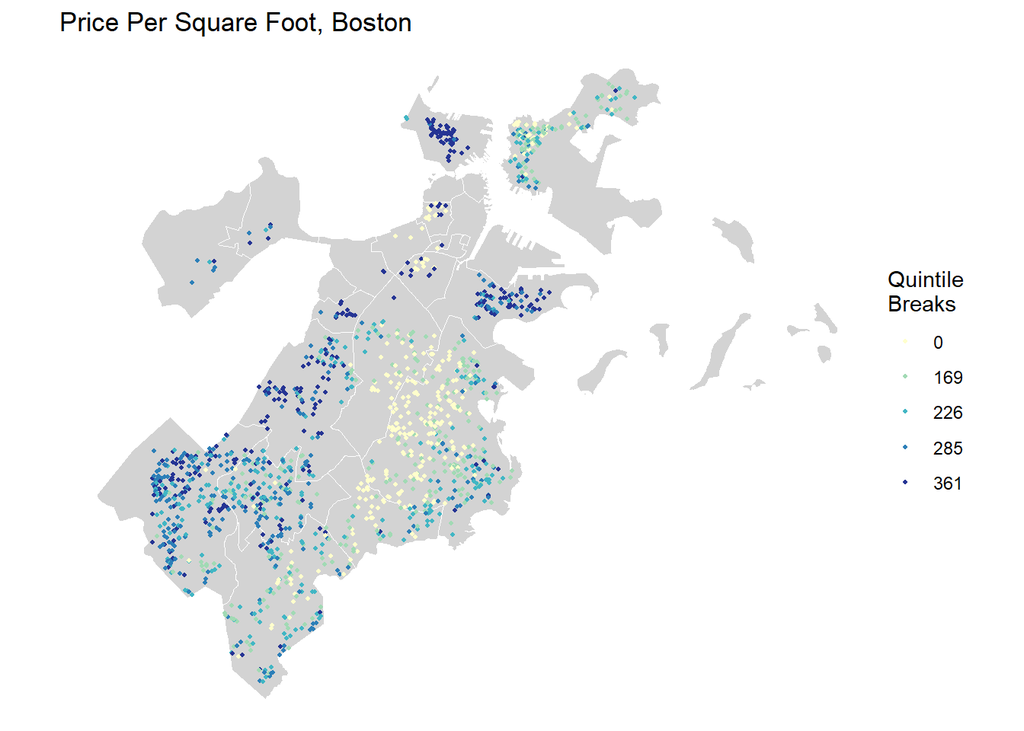

```r
# ggplot, reorder
boston.sf$quintiles <- ntile(boston.sf$PricePerSq, 5)

palette5 <- brewer.pal(5, "YlGnBu")

# Mapping data
ggplot() +
  geom_sf(data = nhoods, fill = "lightgrey", col = "white") +
  geom_sf(data = boston.sf, aes(colour = q5(PricePerSq)),
          show.legend = "point", size = .75) +
  scale_colour_manual(values = palette5,
                   labels=qBr(boston,"PricePerSq"),
                   name="Quintile\nBreaks") +
  labs(title="Price Per Square Foot, Boston") +
  theme_void()
```

### Cleaning Crime Data

Why are we using a filter for `Lat > -1`?

```r
bostonCrimes.sf <-
  bostonCrimes %>%
    filter(OFFENSE_CODE_GROUP == "Aggravated Assault",
           Lat > -1) %>%
    dplyr::select(Lat, Long) %>%
    na.omit() %>%
    st_as_sf(coords = c("Long", "Lat"), crs = "EPSG:4326") %>%
    st_transform('ESRI:102286') %>%
    distinct()
```

### Create Nearest Spatial Features

This is where we do two important things:

- aggregate values within a buffer, and
- create `nearest neighbor` features.

These are primary tools we use to add the local spatial signal to each of the points/rows/observations we are modeling.

#### k nearest neighbor (knn)

The second block of code is using knn for averaging or summing values of a set number of (referred to as `k`) the nearest observations to each observation; it’s *nearest neighbors*. With this, the model can understand the magnitude of values that are *near* each point. This adds a spatial signal to the model.

The number `k` in the `nn_function()` function is the number of neighbors to to values from that are then averaged. Different types of crime (or anything else you measure) will require different values of `k`. *You will have to think about this!*. What could be the importance of `k` when you are making knn features for a violent crime versus and nuisance crime?

```r
# Counts of crime per buffer of house sale
boston.sf$crimes.Buffer <- boston.sf %>%
    st_buffer(660) %>%
    aggregate(mutate(bostonCrimes.sf, counter = 1),., sum) %>%
    pull(counter)

## Nearest Neighbor Feature

boston.sf <-
  boston.sf %>%
    mutate(
      crime_nn1 = nn_function(st_coordinates(boston.sf),
                              st_coordinates(bostonCrimes.sf), k = 1),

      crime_nn2 = nn_function(st_coordinates(boston.sf),
                              st_coordinates(bostonCrimes.sf), k = 2),

      crime_nn3 = nn_function(st_coordinates(boston.sf),
                              st_coordinates(bostonCrimes.sf), k = 3),

      crime_nn4 = nn_function(st_coordinates(boston.sf),
                              st_coordinates(bostonCrimes.sf), k = 4),

      crime_nn5 = nn_function(st_coordinates(boston.sf),
                              st_coordinates(bostonCrimes.sf), k = 5))
```

Let’s create a density map of the crime points.

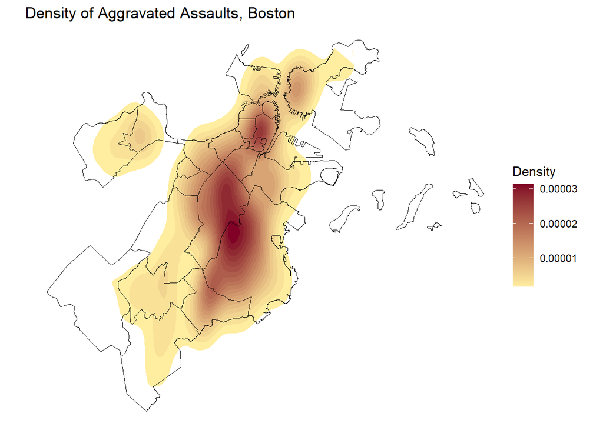

```r
# Create the plot with adjusted plot extent
ggplot() +
  stat_density_2d(data = data.frame(st_coordinates(bostonCrimes.sf)),
                 aes(x = X, y = Y, fill = after_stat(level)),
                 size = 0.1, bins = 20, geom = "polygon") +  # Add 2D density plot
  geom_sf(data = nhoods, fill = "transparent", color = "black") +  # Add neighborhood boundaries
scale_fill_gradient(low = "#FFEDA0", high = "#800026", name = "Density", na.value = "grey40", labels = scales::number_format(scale = 1e3)) +  # Color gradient for density
  labs(title = "Density of Aggravated Assaults, Boston") +
  theme_void()
```

## Analyzing associations

Run these code blocks… Notice the use of `st_drop_geometry()`, this is the correct way to go from a `sf` spatial dataframe to a regular dataframe with no spatial component.

Can somebody walk me through what they do?

Can you give me a one-sentence description of what the takeaway is?

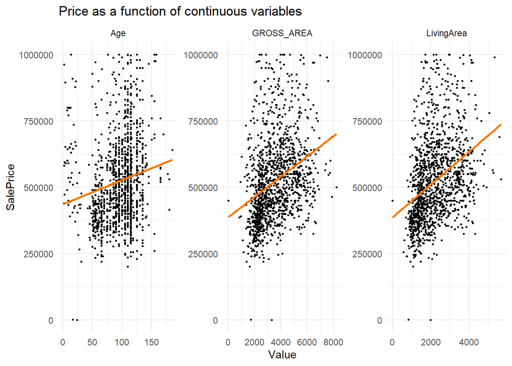

```r
# Remove geometry column (if present), calculate Age, and select relevant variables
boston_cleaned <- st_drop_geometry(boston.sf) %>%
  mutate(Age = 2015 - YR_BUILT) %>%        # Calculate Age based on the year built
  dplyr::select(SalePrice, LivingArea, Age, GROSS_AREA) %>%  # Select relevant variables
  filter(SalePrice <= 1000000, Age < 500)  # Filter data based on conditions

# Reshape data from wide to long format. This is for mapping purposes below.
boston_long <- gather(boston_cleaned, Variable, Value, -SalePrice)

# Create scatterplot with linear regression lines for each variable
ggplot(boston_long, aes(Value, SalePrice)) +   # Set up the plot
  geom_point(size = .5) +                       # Add points for each data point
  geom_smooth(method = "lm", se = FALSE, colour = "#FA7800") +  # Add linear regression lines
  facet_wrap(~Variable, ncol = 3, scales = "free") +  # Create separate plots for each variable
  labs(title = "Price as a function of continuous variables") +  # Set plot title
  theme_minimal()  # Apply a minimal theme to the plot
```

Next, we will look at correlations for the crime variables (kNN)

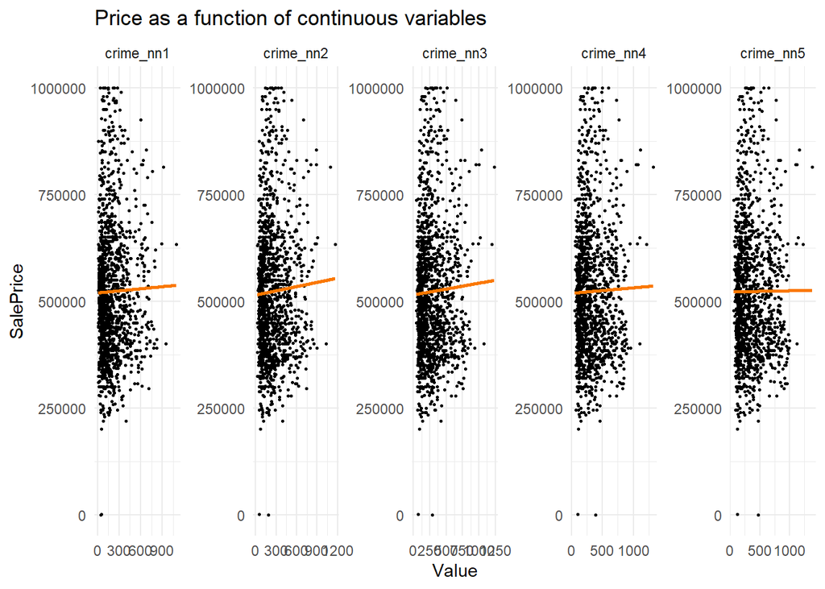

```r
# Clean and prepare the data
boston_cleaned <- boston.sf %>%
  st_drop_geometry() %>%                   # Remove geometry column (if present)
  mutate(Age = 2015 - YR_BUILT) %>%        # Calculate Age based on the year built
  select(SalePrice, starts_with("crime_")) %>%  # Select variables related to crime
  filter(SalePrice <= 1000000)             # Filter data based on SalePrice

# Reshape data from wide to long format
boston_long <- gather(boston_cleaned, Variable, Value, -SalePrice)

# Create scatterplot with linear regression lines for each variable
ggplot(boston_long, aes(Value, SalePrice)) +   # Set up the plot
  geom_point(size = .5) +                       # Add points for each data point
  geom_smooth(method = "lm", se = FALSE, colour = "#FA7800") +  # Add linear regression lines
  facet_wrap(~Variable, nrow = 1, scales = "free") +  # Create separate plots for each variable
  labs(title = "Price as a function of continuous variables") +  # Set plot title
  theme_minimal()  # Apply a minimal theme to the plot
```

## Correlation matrix

A correlation matrix gives us the pairwise correlation of each set of features in our data. It is usually advisable to include the target/outcome variable in this so we can understand which features are related to it.

Some things to notice in this code; we use `select_if()` to select only the features that are numeric. This is really handy when you don’t want to type or hard-code the names of your features; `ggcorrplot()` is a function from the `ggcorrplot` package.

**Let’s take a few minutes to interpret this**

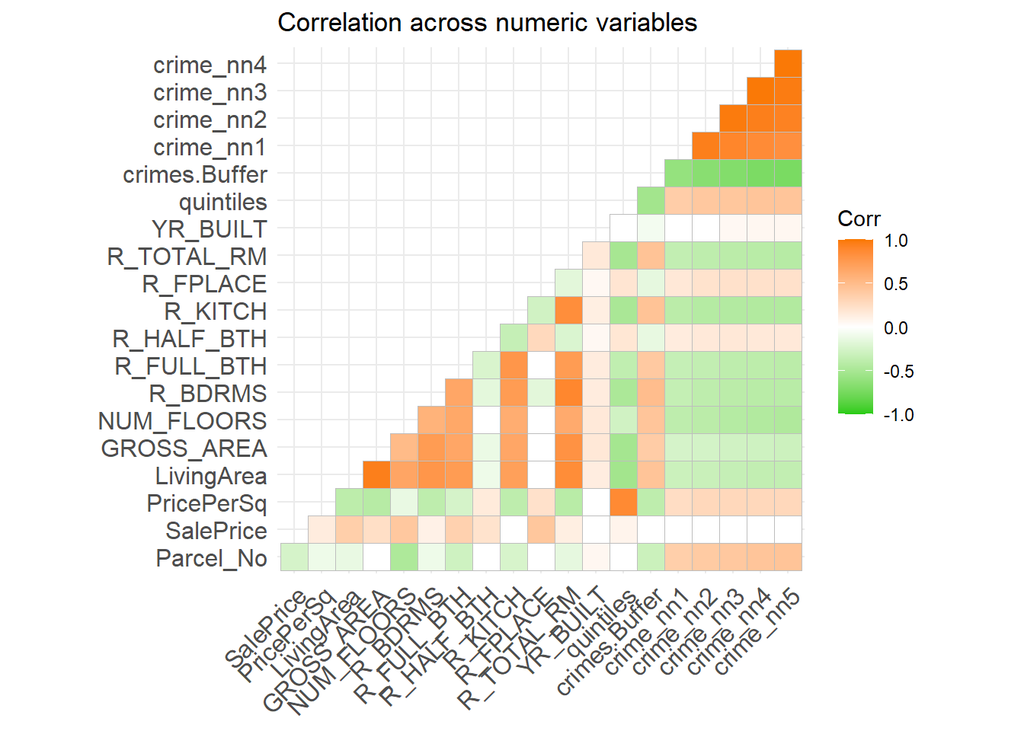

```r
# Select only numeric variables and remove rows with missing values
numericVars <- boston.sf %>%
  st_drop_geometry() %>%  # Remove geometry column if present
  select_if(is.numeric) %>%  # Select only numeric variables
  na.omit()  # Remove rows with missing values

# Calculate correlation matrix
correlation_matrix <- cor(numericVars)

# Create correlation plot
ggcorrplot(
  correlation_matrix,  # Correlation matrix
  p.mat = cor_pmat(numericVars),  # p-values for significance
  colors = c("#25CB10", "white", "#FA7800"),  # Custom color palette
  type = "lower",  # Lower triangle of the correlation matrix
  insig = "blank"  # Hide insignificant correlations
) +
labs(title = "Correlation across numeric variables")  # Set plot title
```

```
## Correlation computed with
## • Method: 'pearson'
## • Missing treated using: 'pairwise.complete.obs'
```

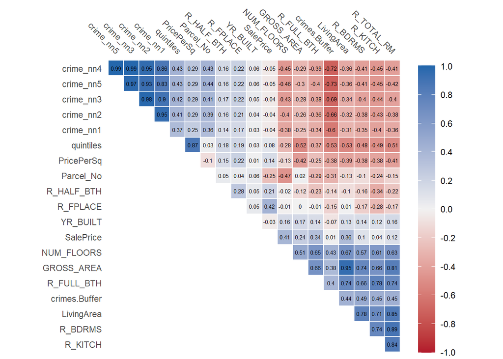

```r
# yet another way to plot the correlation plot using the corrr library
numericVars %>%
  correlate() %>%
  autoplot() +
  geom_text(aes(label = round(r,digits=2)),size = 2)
```

# Univarite correlation -> multi-variate OLS regression

### Pearson’s r - Correlation Coefficient

Pearson’s r Learning links: * [Pearson Correlation Coefficient (r) | Guide & Examples](https://www.scribbr.com/statistics/pearson-correlation-coefficient/) * [Correlation Test Between Two Variables in R](http://www.sthda.com/english/wiki/correlation-test-between-two-variables-in-r)

Note: the use of the `ggscatter()` function from the `ggpubr` package to plot the *Pearson’s rho* or *Pearson’s r* statistic; the Correlation Coefficient. This number can also be squared and represented as `r2`. However, this differs from the `R^2` or `R2` or “R-squared” of a linear model fit, known as the Coefficient of Determination. This is explained a bit more below.

```r
boston_sub_200k <- st_drop_geometry(boston.sf) %>%
filter(SalePrice <= 2000000)

cor.test(boston_sub_200k$LivingArea,
         boston_sub_200k$SalePrice,
         method = "pearson")
```

```
##
##  Pearson's product-moment correlation
##
## data:  boston_sub_200k$LivingArea and boston_sub_200k$SalePrice
## t = 13.415, df = 1447, p-value < 2.2e-16
## alternative hypothesis: true correlation is not equal to 0
## 95 percent confidence interval:
##  0.2859924 0.3776199
## sample estimates:
##       cor
## 0.3325908
```

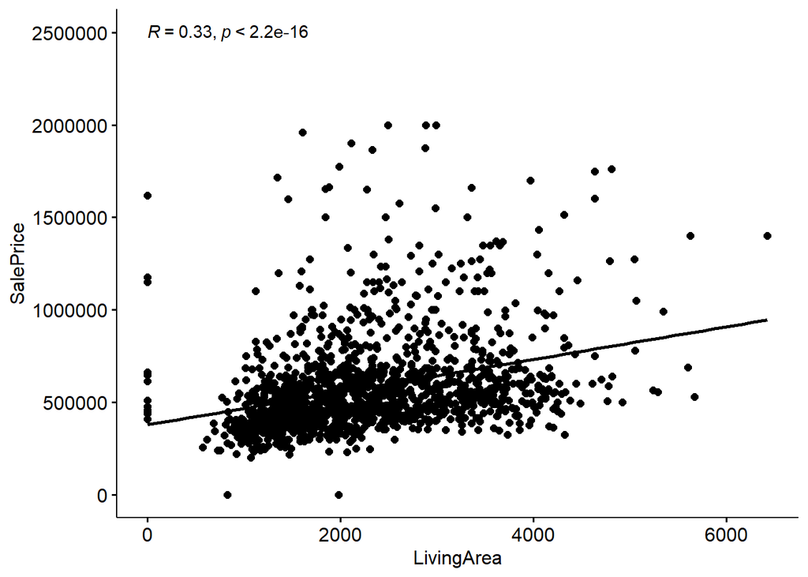

```r
ggscatter(boston_sub_200k,
          x = "LivingArea",
          y = "SalePrice",
          add = "reg.line") +
  stat_cor(label.y = 2500000)
```

## Univarite Regression

### R2 - Coefficient of Determination

Discussed above, the `R^2` or “R-squared” is a common way to validate the predictions of a linear model. Below we run a linear model on our data with the `lm()` function and get the output in our R terminal. At first this is an intimidating amount of information! Here is a [great resource](https://towardsdatascience.com/understanding-linear-regression-output-in-r-7a9cbda948b3) to understand how that output is organized and what it means.

What we are focusing on here is that `R-squared`, `Adjusted R-squared` and the `Coefficients`.

What’s the `R2` good for as a diagnostic of model quality?

Can somebody interpret the coefficient?

Note: Here we use `ggscatter` with the `..rr.label` argument to show the `R2` Coefficient of Determination.

```r
# Fit linear regression model
livingReg <- lm(SalePrice ~ LivingArea, data = boston_sub_200k)

# Print summary of regression results
summary(livingReg)
```

```
##
## Call:
## lm(formula = SalePrice ~ LivingArea, data = boston_sub_200k)
##
## Residuals:
##     Min      1Q  Median      3Q     Max
## -553037 -143649  -61127   61996 1439918
##
## Coefficients:
##              Estimate Std. Error t value Pr(>|t|)
## (Intercept) 3.784e+05  1.606e+04   23.55   <2e-16 ***
## LivingArea  8.835e+01  6.586e+00   13.41   <2e-16 ***
## ---
## Signif. codes:  0 '***' 0.001 '**' 0.01 '*' 0.05 '.' 0.1 ' ' 1
##
## Residual standard error: 245200 on 1447 degrees of freedom
## Multiple R-squared:  0.1106, Adjusted R-squared:   0.11
## F-statistic:   180 on 1 and 1447 DF,  p-value: < 2.2e-16
```

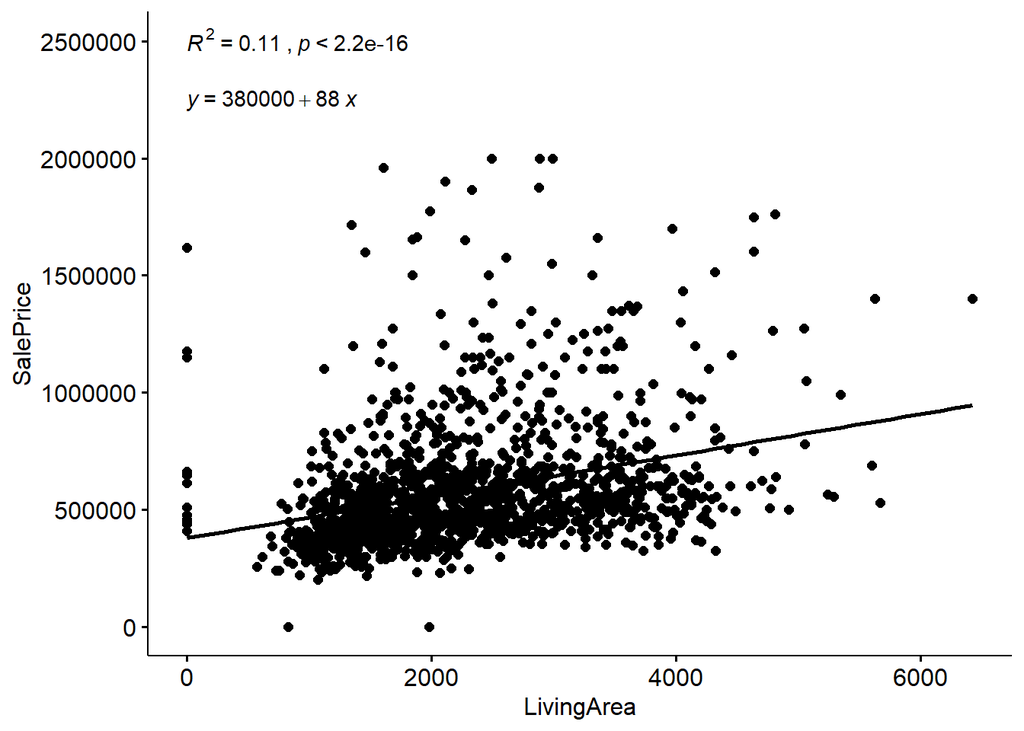

```r
# Create scatterplot with regression line
ggscatter(
  data = boston_sub_200k,
  x = "LivingArea",            # Predictor variable (x-axis)
  y = "SalePrice",             # Outcome variable (y-axis)
  add = "reg.line"             # Add regression line to the plot
) +
  # Add correlation coefficient and p-value to the plot
  stat_cor(
    aes(label = paste(..rr.label.., ..p.label.., sep = "~`,`~")),
    label.y = 2500000          # Adjust label position on the y-axis
  ) +
  # Add equation of the regression line to the plot
  stat_regline_equation(label.y = 2250000)
```

## Prediction example

Make a prediction using the coefficient, intercept etc.,

```r
# View coefficients of the linear regression model
coefficients(livingReg)
```

```
##  (Intercept)   LivingArea
## 378370.01571     88.34939
```

```r
# Define new LivingArea value
new_LivingArea <- 4000

# Calculate predicted SalePrice "by hand"
predicted_by_hand <- 378370.01571 + 88.34939 * new_LivingArea

# Predict SalePrice using the predict() function
predicted_with_predict <- predict(livingReg, newdata = data.frame(LivingArea = 4000))

# View the predicted values
predicted_by_hand
```

```
## [1] 731767.6
```

```r
predicted_with_predict
```

```
##        1
## 731767.6
```

## Multivariate Regression

Let’s take a look at this regression - how are we creating it?

What’s up with these categorical variables?

Better R-squared - does that mean it’s a better model?

```r
reg1 <- lm(SalePrice ~ ., data = boston_sub_200k %>%
                                 dplyr::select(SalePrice, LivingArea,
                                               GROSS_AREA, R_TOTAL_RM, NUM_FLOORS,
                                               R_BDRMS, R_FULL_BTH, R_HALF_BTH,
                                               R_KITCH, R_AC, R_FPLACE))

summary(reg1)
```

```
##
## Call:
## lm(formula = SalePrice ~ ., data = boston_sub_200k %>% dplyr::select(SalePrice,
##     LivingArea, GROSS_AREA, R_TOTAL_RM, NUM_FLOORS, R_BDRMS,
##     R_FULL_BTH, R_HALF_BTH, R_KITCH, R_AC, R_FPLACE))
##
## Residuals:
##     Min      1Q  Median      3Q     Max
## -723474 -122751  -27505   78864 1226574
##
## Coefficients:
##               Estimate Std. Error t value Pr(>|t|)
## (Intercept)  213685.95   31825.29   6.714 2.71e-11 ***
## LivingArea      100.58      26.76   3.758 0.000178 ***
## GROSS_AREA      -24.82      15.28  -1.624 0.104691
## R_TOTAL_RM     2519.51    4454.50   0.566 0.571747
## NUM_FLOORS   144085.60   14444.73   9.975  < 2e-16 ***
## R_BDRMS      -10774.72    5979.44  -1.802 0.071761 .
## R_FULL_BTH    94663.43   12651.65   7.482 1.27e-13 ***
## R_HALF_BTH    12140.38   11982.32   1.013 0.311139
## R_KITCH     -118956.74   16262.10  -7.315 4.26e-13 ***
## R_ACD       -107663.40  212807.56  -0.506 0.612991
## R_ACN        -90840.14   18852.80  -4.818 1.60e-06 ***
## R_ACU        350277.05   63190.81   5.543 3.53e-08 ***
## R_FPLACE      80846.87    9649.41   8.378  < 2e-16 ***
## ---
## Signif. codes:  0 '***' 0.001 '**' 0.01 '*' 0.05 '.' 0.1 ' ' 1
##
## Residual standard error: 212100 on 1436 degrees of freedom
## Multiple R-squared:  0.3393, Adjusted R-squared:  0.3337
## F-statistic: 61.44 on 12 and 1436 DF,  p-value: < 2.2e-16
```

## Marginal Response Plots

Let’s try some of these out. They help you learn more about the relationships in the model.

Plot of Marginal Response:

effect_plot() is used to visualize the marginal response of the outcome variable (dependent variable) with respect to the predictor variable R_BDRMS in the linear regression model reg1. pred = R_BDRMS specifies R_BDRMS as the predictor variable to be plotted. interval = TRUE adds confidence intervals to the plot. plot.points = TRUE includes individual data points in the plot.

Interpretation of Marginal Effects:

The plot of marginal response helps visualize how the outcome variable changes as a predictor variable varies, holding other variables constant. It provides insights into the relationship between the predictor variable and the outcome variable, allowing researchers to understand the direction and strength of the relationship.

Plot Coefficients:

plot_summs() is used to plot coefficients from the regression model reg1. scale = TRUE scales the coefficients for better comparison if the predictors are on different scales. Plot Multiple Model Coefficients:

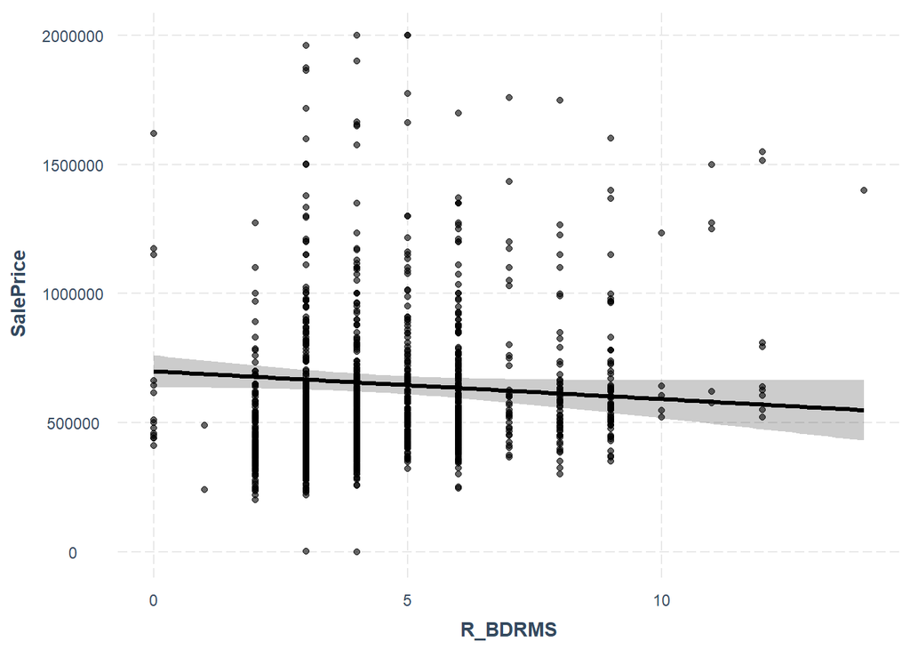

```r
## Plot of marginal response
effect_plot(reg1, pred = R_BDRMS, interval = TRUE, plot.points = TRUE)
```

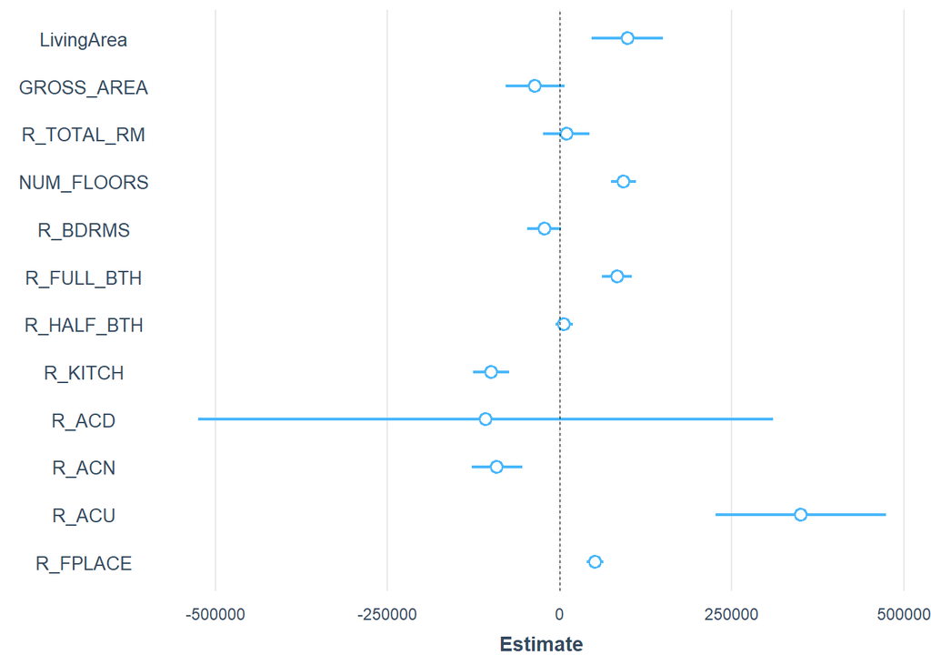

```r
## Plot coefficients
plot_summs(reg1, scale = TRUE)
```

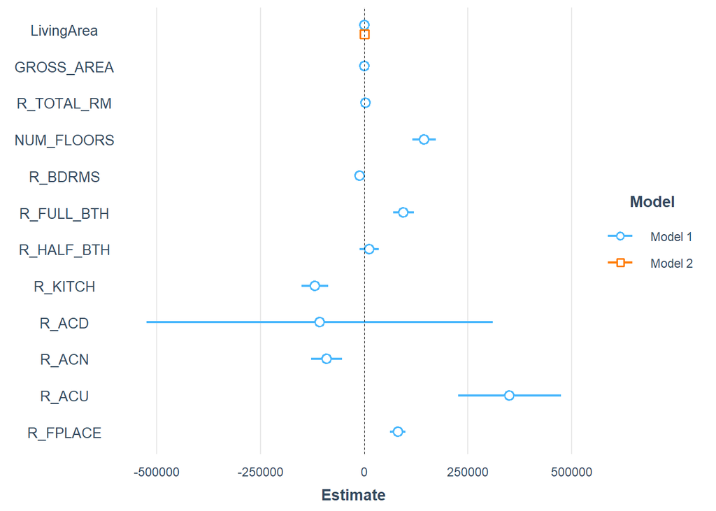

```r
## plot multiple model coeffs
plot_summs(reg1, livingReg)
```

# cross validation

This is a slightly nicer way of doing the CV as compared to the warm-up example.

```r
# Load necessary libraries

# Define the control parameters for k-fold cross-validation
control <- trainControl(method = "cv",    # Use k-fold cross-validation
                        number = 10,      # Number of folds
                        verboseIter = TRUE,  # Show verbose output
                        returnData = FALSE,  # Don't return resampled data
                        savePredictions = TRUE,  # Save predictions
                        classProbs = FALSE,  # Don't compute class probabilities
                        summaryFunction = defaultSummary)  # Use default summary function

# Train the linear regression model using k-fold cross-validation
lm_cv <- train(SalePrice ~ LivingArea,  # Formula for the linear regression model
               data = boston_sub_200k,  # Dataset
               method = "lm",           # Specify "lm" for linear regression
               trControl = control)     # Use the defined control parameters
# View the cross-validation results
print(lm_cv)
```

```
## Linear Regression
##
## No pre-processing
## Resampling: Cross-Validated (10 fold)
## Summary of sample sizes: 1304, 1304, 1303, 1304, 1305, 1303, ...
## Resampling results:
##
##   RMSE      Rsquared   MAE
##   244655.1  0.1146693  166341.9
##
## Tuning parameter 'intercept' was held constant at a value of TRUE
```

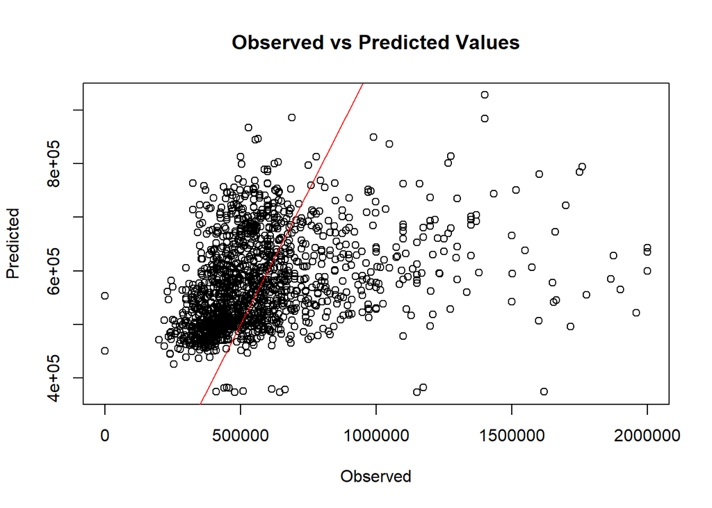

```r
# Plot observed versus predicted values
plot(lm_cv$pred$obs, lm_cv$pred$pred,
     xlab = "Observed", ylab = "Predicted",
     main = "Observed vs Predicted Values")

# Add a diagonal line for reference
abline(0, 1, col = "red")
```

RMSE (Root Mean Squared Error):

RMSE is the square root of the average of the squared differences between predicted and observed values. It penalizes large errors more heavily than small errors because it squares the differences. RMSE is sensitive to outliers because of the squaring operation.

MAE (Mean Absolute Error):

MAE is the average of the absolute differences between predicted and observed values. It treats all errors equally regardless of their magnitude. MAE is less sensitive to outliers compared to RMSE because it does not square the differences.

The case of a LOOCV

```r
# Set up leave-one-out cross-validation
control <- trainControl(method = "LOOCV",     # Use leave-one-out cross-validation
                        number = nrow(boston_sub_200k),  # Number of folds = number of observations
                        verboseIter = TRUE,  # Show verbose output
                        returnData = FALSE,  # Don't return resampled data
                        savePredictions = TRUE,  # Save predictions
                        classProbs = FALSE,  # Don't compute class probabilities
                        summaryFunction = defaultSummary)  # Use default summary function

# Train the linear regression model using leave-one-out cross-validation
lm_loocv <- train(SalePrice ~ LivingArea,  # Formula for the linear regression model
                  data = boston_sub_200k,  # Dataset
                  method = "lm",           # Specify "lm" for linear regression
                  trControl = control)     # Use the defined control parameters
# View the cross-validation results
print(lm_loocv)
```

```
## Linear Regression
##
## No pre-processing
## Resampling: Leave-One-Out Cross-Validation
## Summary of sample sizes: 1448, 1448, 1448, 1448, 1448, 1448, ...
## Resampling results:
##
##   RMSE      Rsquared   MAE
##   245389.9  0.1078112  166415.2
##
## Tuning parameter 'intercept' was held constant at a value of TRUE
```

How to interpret? Overall, based on these metrics:

The model’s RMSE and MAE suggest that the average prediction error is approximately 245,389.9 and 166,415.2, respectively.

The Rsquared value indicates that around 10.78% of the variability in SalePrice is explained by the model’s predictor variables.

## Try to engineer a ‘dummy variable’ out of the other variables in an attempt to parameterize a variable that suggests a big or fancy house or levels of fanciness.

## How does this affect your model?